# 05_visualization_Белов_Фёдор_ПМ24-5

## Лабораторная работа 5.1

**Данная работа подразумевает построение рисунков. В связи с этим задания, для которых не будет виден результат выполнения ячеек (получившиеся рисунки), засчитаны не будут вне зависимости от правильности решения.**

### Визуализация данных при помощи пакета `matplotlib`

**В данном блоке задач не разрешается использовать другие пакеты для визуализации, кроме `matplotlib`.**

1. В файле `average_ratings.npy` содержится информация о среднем рейтинге 3 рецептов за период с 01.01.2019 по 30.12.2021. При помощи пакета `matplotlib` в *одной системе координат* (на одной картинке) изобразите три временных ряда, соответствующих средним рейтингам этих рецептов.

По горизонтальной оси располагается номер дня (0, 1, 2, ...), по вертикальной - средний рейтинг рецептов в этот день.

Названия рецептов и их индексы в файле `average_ratings.npy`:

```
0: waffle iron french toast
1: zwetschgenkuchen bavarian plum cake
2: lime tea
```

Результатом работы является визуализация, на которой:

- добавлена подпись горизонтальной оси с текстом "Номер дня"
- добавлена подпись вертикальной оси с текстом "Средний рейтинг"
- добавлена подпись рисунка с текстом "Изменение среднего рейтинга трех рецептов"
- каждый из временных рядов имеет уникальный цвет
- добавлена легенда, на которой отображается название каждого из рецептов

*Примечание* : для считывания файла воспользуйтесь функцией `np.load`.

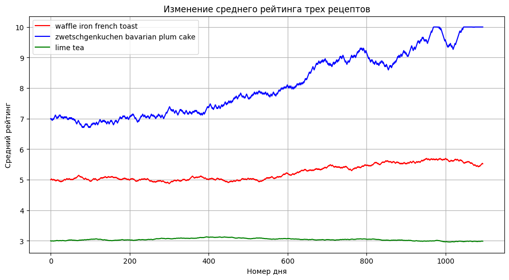

```python
import numpy as np
import matplotlib.pyplot as plt

ratings = np.load('average_ratings.npy')

days = np.arange(len(ratings[0]))

recipe_names = [
    "waffle iron french toast",
    "zwetschgenkuchen bavarian plum cake",
    "lime tea"
]

plt.figure(figsize=(12, 6))

colors = ['red', 'blue', 'green']

for i, (recipe_rating, color) in enumerate(zip(ratings, colors)):
    plt.plot(days, recipe_rating, label=recipe_names[i], color=color)

plt.title('Изменение среднего рейтинга трех рецептов')
plt.xlabel('Номер дня')
plt.ylabel('Средний рейтинг')
plt.legend()
plt.grid(True)
plt.show()
```

2. Измените визуализацию, полученную в задании 1, таким образом, чтобы по горизонтальной оси отображались года, а между двумя соседними годами располагались засечки, соответствующие месяцам. Для этого создайте диапазон дат от 01.01.2019 по 30.12.2021 с шагом в один день (например, [вот так](https://pandas.pydata.org/docs/reference/api/pandas.date_range.html)) и используйте этот диапазон при вызове метода `plot`. Далее настройте `major_locator` и `minor_locator` горизонтальной оси (подробнее см. [здесь](https://matplotlib.org/stable/gallery/text_labels_and_annotations/date.html))

Примените к получившемуся рисунку цвета графиков, подписи, легенду из задания 1. Измените подпись горизонтальной оси, написав там слово "Дата".

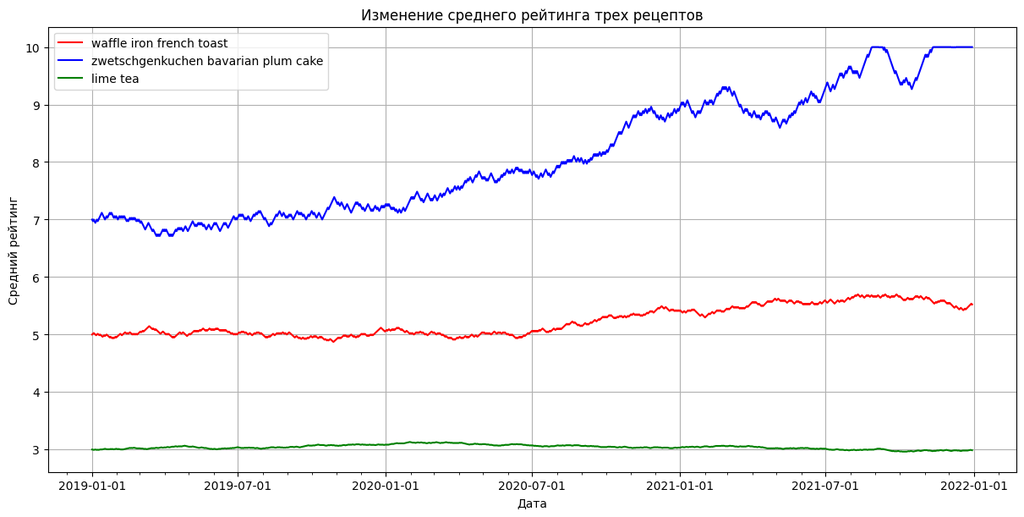

```python
import numpy as np
import matplotlib.pyplot as plt
import pandas as pd
import matplotlib.dates as mdates

ratings = np.load('average_ratings.npy')
dates = pd.date_range('1/1/2019', '30/12/2021')

recipe_names = [
    "waffle iron french toast",
    "zwetschgenkuchen bavarian plum cake",
    "lime tea"
]

fig, ax = plt.subplots(figsize=(12, 6), layout='constrained')

colors = ['red', 'blue', 'green']

for i, (recipe_rating, color) in enumerate(zip(ratings, colors)):
    ax.plot(dates, recipe_rating, label=recipe_names[i], color=color)
ax.xaxis.set_major_locator(mdates.MonthLocator(bymonth=(1, 7)))
ax.xaxis.set_minor_locator(mdates.MonthLocator())
ax.grid(True)
ax.set_ylabel('Средний рейтинг')
ax.set_xlabel('Дата')
ax.legend()

ax.set_title('Изменение среднего рейтинга трех рецептов')
ax.xaxis.set_major_formatter(mdates.DateFormatter('%Y-%m-%d'))

plt.show()
```

3. Измените визуализацию, полученную в задании 2, разбив одну картинку на три, расположенных друг под другом. Три изображения должны иметь одну общую горизонтальную ось (каждое изображение засечки в нижней части, но значения этих засечек находятся только под самым нижним изображением). Примените к получившемуся рисунку цвета графиков, подписи, легенду из задания 2.

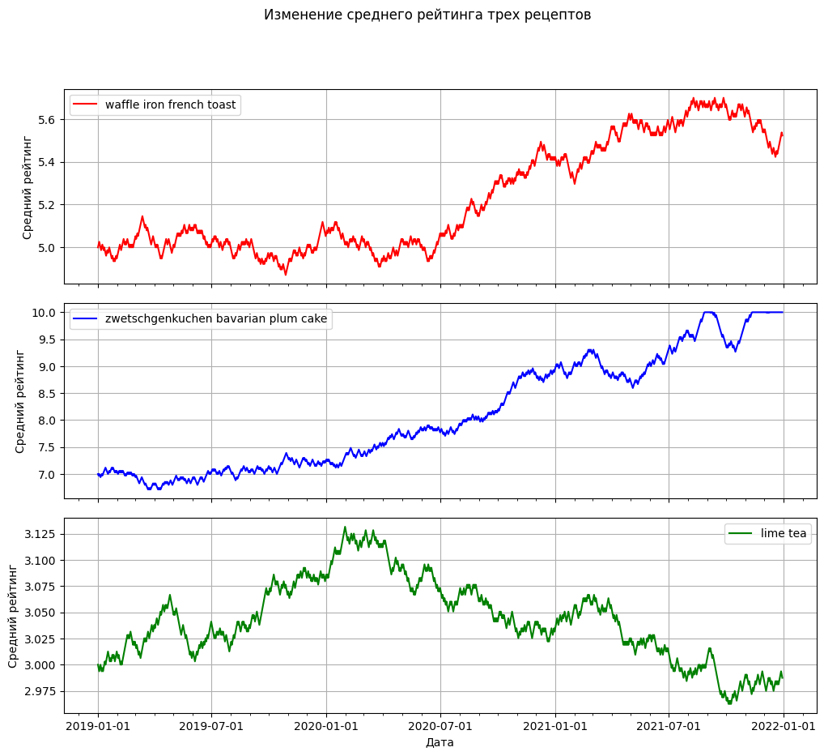

```python
import numpy as np
import matplotlib.pyplot as plt
import pandas as pd
import matplotlib.dates as mdates

ratings = np.load('average_ratings.npy')
dates = pd.date_range('1/1/2019', '30/12/2021')

recipe_names = [
    "waffle iron french toast",
    "zwetschgenkuchen bavarian plum cake",
    "lime tea"
]

fig, (ax1, ax2, ax3) = plt.subplots(3, 1, figsize=(12, 10), sharex=True)
plt.subplots_adjust(hspace=0.1)

colors = ['red', 'blue', 'green']

ax1.plot(dates, ratings[0], color=colors[0], label=recipe_names[0])
ax1.legend()
ax1.grid(True)
ax1.set_ylabel('Средний рейтинг')

ax2.plot(dates, ratings[1], color=colors[1], label=recipe_names[1])
ax2.legend()
ax2.grid(True)
ax2.set_ylabel('Средний рейтинг')

ax3.plot(dates, ratings[2], color=colors[2], label=recipe_names[2])
ax3.legend()
ax3.grid(True)
ax3.set_ylabel('Средний рейтинг')
ax3.set_xlabel('Дата')

ax3.xaxis.set_major_locator(mdates.MonthLocator(bymonth=(1, 7)))
ax3.xaxis.set_minor_locator(mdates.MonthLocator())
ax3.xaxis.set_major_formatter(mdates.DateFormatter('%Y-%m-%d'))

fig.suptitle('Изменение среднего рейтинга трех рецептов')

plt.show()
```

4. В файле `visitors.npy` представлена информация о количестве посетителей сайта в течении первых 100 дней после объявления сайтом акции. Постройте график изменения количества пользователей в зависимости от дня в двух вариантах, расположенных рядом по горизонтале. В обоих случаях изобразите график в виде ломаной, но в первом случае оставьте линейный масштаб осей, а во втором случае сделайте вертикальную ось в логарифмическом масштабе. Добавьте на обе картинки подпись над этим графиком к текстом $y(x)=\lambda e^{-\lambda x}$

Добавьте на оба изображения красную горизонтальную линию на уровне $y=100$. Добавьте на обе картинки подпись над этой линией с текстом $y(x)=100$

Добавьте на оба изображения подписи осей; горизонтальную ось подпишите текстом "Количество дней с момента акции", вертикальную - "Число посетителей".

Добавьте общий заголовок для фигуры с текстом "Изменение количества пользователей в линейном и логарифмическом масштабе".

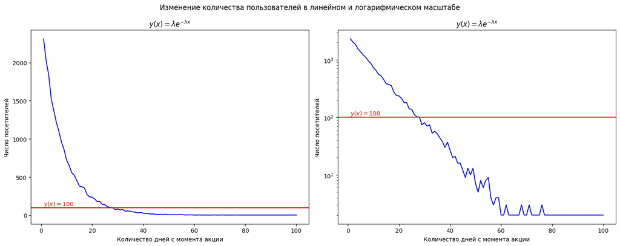

```python
import numpy as np
import matplotlib.pyplot as plt

visitors = np.load('visitors.npy')
days = np.arange(1, 101)

fig, (ax1, ax2) = plt.subplots(1, 2, figsize=(15, 6))

ax1.plot(days, visitors, 'b-')
ax1.axhline(y=100, color='r', linestyle='-')
ax1.set_xlabel('Количество дней с момента акции')
ax1.set_ylabel('Число посетителей')
ax1.set_title('$y(x)=\lambda e^{-\lambda x}$')

ax2.plot(days, visitors, 'b-')
ax2.axhline(y=100, color='r', linestyle='-')
ax2.set_xlabel('Количество дней с момента акции')
ax2.set_ylabel('Число посетителей')
ax2.set_yscale('log')
ax2.set_title('$y(x)=\lambda e^{-\lambda x}$')

plt.suptitle('Изменение количества пользователей в линейном и логарифмическом масштабе')

ax1.text(1, 100, '$y(x)=100$', color='r', va='bottom')
ax2.text(1, 100, '$y(x)=100$', color='r', va='bottom')

plt.tight_layout()

plt.savefig('visitors_plot.png')
plt.show()
```

## Лабораторная работа 5.2

### Визуализация данных на основе структур `pandas`.

Для продолжения работы загрузите таблицы recipes и reviews (**ЛР2**)

```python
import pandas as pd
reviews = pd.read_csv("reviews_sample.csv")
recipes = pd.read_csv("recipes_sample.csv")
```

5. Назовем рецепты короткими, если они занимают строго меньше 5 минут; средними, если они занимают от 5 до 50 минут (не включая 50), и длинными, если они занимают от 50 минут и больше. Сгруппируйте все рецепты по данному признаку и для каждой группы посчитайте 2 величины: среднее количество шагов рецептов в группе и размер группы. При помощи методов структур `pandas` постройте столбчатую диаграмму, где каждый столбец означает группу (короткие, средние или длинные рецепты), а высота столбца обозначает среднее количество шагов рецептов в группе. Рядом по горизонтали разместите круговую диаграмму, на которой отображены размеры каждой из групп.

Добавьте следующие подписи:

- по горизонтальной оси под столбчатой диаграммой напишите "Группа рецептов"
- по вертикальной оси слева от столбчатой диаграммы напишите "Средняя длительность"
- над круговой диаграммой напишите "Размеры групп рецептов"

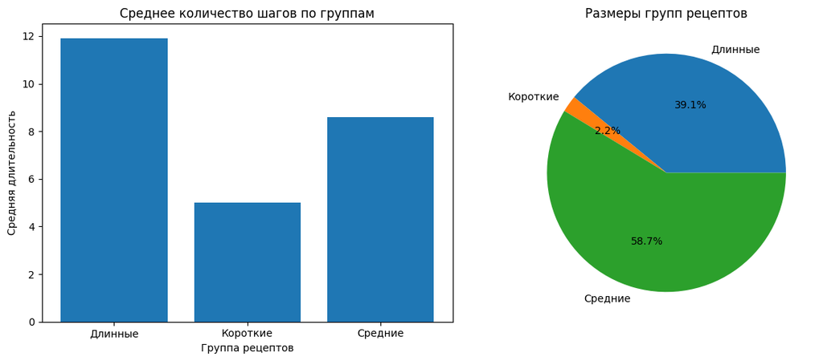

```python
import matplotlib.pyplot as plt

def categorize_time(minutes):
    if minutes < 5:
        return 'Короткие'
    elif 5 <= minutes < 50:
        return 'Средние'
    else:
        return 'Длинные'

recipes['category'] = recipes['minutes'].apply(categorize_time)

group_stats = recipes.groupby('category').agg({
    'n_steps': 'mean',
    'id': 'count'
}).rename(columns={'n_steps': 'avg_steps', 'id': 'count'})

fig, (ax1, ax2) = plt.subplots(1, 2, figsize=(12, 5))
ax1.bar(group_stats.index, group_stats['avg_steps'])
ax1.set_xlabel('Группа рецептов')
ax1.set_ylabel('Средняя длительность')
ax1.set_title('Среднее количество шагов по группам')

ax2.pie(group_stats['count'], labels=group_stats.index, autopct='%1.1f%%')
ax2.set_title('Размеры групп рецептов')

plt.tight_layout()
plt.show()
```

6. Из всего множества отзывов оставьте только те, которые были даны в 2008 и 2009 годах. Воспользовавшись возможностями метода `pd.DataFrame.plot.hist`, постройте 2 гистограммы столбца `rating`. Гистограммы должны быть расположены рядом по горизонтали. Левая гистограмма соотвествует 2008 году, правая - 2009 году. Добавьте общую подпись для рисунка с текстом "Гистограммы рейтинга отзывов в 2008 и 2009 годах". Добейтесь того, чтобы подпись вертикальной оси правого рисунка не "наезжала" на левый рисунок.

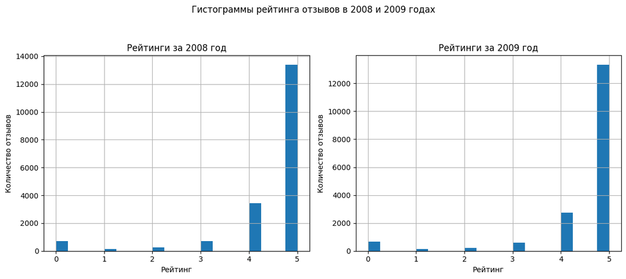

```python
import pandas as pd
import matplotlib.pyplot as plt

reviews = pd.read_csv("reviews_sample.csv")

reviews['date'] = pd.to_datetime(reviews['date'])

reviews['year'] = reviews['date'].dt.year

reviews_2008_2009 = reviews[reviews['year'].isin([2008, 2009])]

fig, (ax1, ax2) = plt.subplots(1, 2, figsize=(12, 5))

reviews_2008 = reviews_2008_2009[reviews_2008_2009['year'] == 2008]
reviews_2008['rating'].hist(ax=ax1, bins=20)
ax1.set_title('Рейтинги за 2008 год')
ax1.set_xlabel('Рейтинг')
ax1.set_ylabel('Количество отзывов')

reviews_2009 = reviews_2008_2009[reviews_2008_2009['year'] == 2009]
reviews_2009['rating'].hist(ax=ax2, bins=20)
ax2.set_title('Рейтинги за 2009 год')
ax2.set_xlabel('Рейтинг')
ax2.set_ylabel('Количество отзывов')

plt.suptitle('Гистограммы рейтинга отзывов в 2008 и 2009 годах', y=1.05)

plt.tight_layout()

plt.show()
```

### Визуализация данных при помощи пакета `seaborn`

7. При помощи пакета `seaborn` постройте диаграмму рассеяния двух столбцов из таблицы `recipes`: `n_steps` и `n_ingredients`. Укажите в качестве группирующей переменной (hue) категориальную длительность рецепта (короткий, средний или длинные; см. задание 5).

Добавьте заголовок рисунка "Диаграмма рассеяния n_steps и n_ingredients"

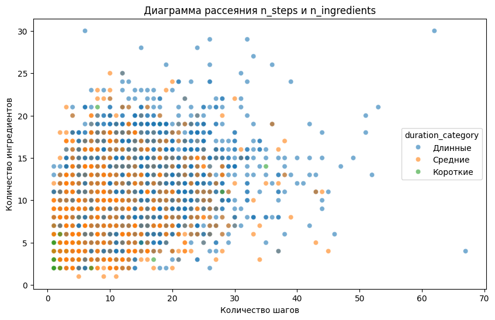

```python
import pandas as pd
import seaborn as sns
import matplotlib.pyplot as plt

recipes = pd.read_csv("recipes_sample.csv")
recipes['duration_category'] = recipes['minutes'].apply(categorize_time)

plt.figure(figsize=(10, 6))
sns.scatterplot(data=recipes,
                x='n_steps',
                y='n_ingredients',
                hue='duration_category',
                alpha=0.6)

plt.title('Диаграмма рассеяния n_steps и n_ingredients')
plt.xlabel('Количество шагов')
plt.ylabel('Количество ингредиентов')

plt.show()
```

8. Объедините две таблицы `recipes` и `reviews` и постройте корреляционную матрицу на основе столбцов "minutes", "n_steps", "n_ingredients" и "rating". При помощи пакета `seaborn` визуализируйте полученную матрицу в виде тепловой карты (heatmap).

Добавьте в ячейки тепловой карты подписи (значения к-та корреляции). Измените цветовую палитру на `YlOrRd`.

Добавьте заголовок рисунка "Корреляционная матрица числовых столбцов таблиц recipes и reviews"

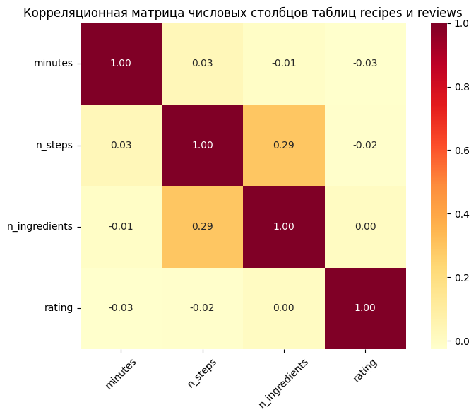

```python
import pandas as pd
import seaborn as sns
import matplotlib.pyplot as plt

recipes = pd.read_csv("recipes_sample.csv")
reviews = pd.read_csv("reviews_sample.csv")

merged_df = pd.merge(recipes, reviews, left_on='id', right_on='recipe_id')

columns_of_interest = ['minutes', 'n_steps', 'n_ingredients', 'rating']
correlation_matrix = merged_df[columns_of_interest].corr()

plt.figure(figsize=(8, 6))
sns.heatmap(correlation_matrix,
            annot=True,
            fmt='.2f',
            cmap='YlOrRd',
            square=True)

plt.title('Корреляционная матрица числовых столбцов таблиц recipes и reviews')
plt.xticks(rotation=45)
plt.yticks(rotation=0)

plt.tight_layout()

plt.show()
```